# Assignment_Week2

Jan Willem

28-2-2021

## Assignment

1 Code for reading in the dataset and/or processing the data  
2 Histogram of the total number of steps taken each day  
3 Mean and median number of steps taken each day  
4 Time series plot of the average number of steps taken  
5 The 5-minute interval that, on average, contains the maximum number of steps  
6 Code to describe and show a strategy for imputing missing data  
7 Histogram of the total number of steps taken each day after missing values are imputed  
8 Panel plot comparing the average number of steps taken per 5-minute interval across weekdays and weekends  
9 All of the R code needed to reproduce the results (numbers, plots, etc.) in the report

### 1 Code for reading in the dataset and/or processing the data

Download the data

```r
options(scipen = 999)
#Download and unzip files
download.file(url = "https://d396qusza40orc.cloudfront.net/repdata%2Fdata%2Factivity.zip"
              , destfile = paste(getwd(), "repdata_data_activity.zip", sep = "/"))
#unzip(zipfile = "repdata_data_activity.zip")
unzip(zipfile =  paste(getwd(), "repdata_data_activity.zip", sep = "/"))
```

Check for packages that are needed

[output not shown]

Read file and look at the head of the file

```r
#paste(getwd(), , sep = "/"))
activity<-read.csv(file=paste(getwd(), "activity.csv" , sep = "/"), header=TRUE, sep=",")
#activity<-read.csv(file="activity.csv" , header=TRUE, sep=",")
head(activity)
```

```
##   steps       date interval
## 1    NA 2012-10-01        0
## 2    NA 2012-10-01        5
## 3    NA 2012-10-01       10
## 4    NA 2012-10-01       15
## 5    NA 2012-10-01       20
## 6    NA 2012-10-01       25
```

Change datatype date to date()

```r
activity$date<-as.Date(activity$date)
str(activity)
```

```
## 'data.frame':    17568 obs. of  3 variables:
##  $ steps   : int  NA NA NA NA NA NA NA NA NA NA ...
##  $ date    : Date, format: "2012-10-01" "2012-10-01" ...
##  $ interval: int  0 5 10 15 20 25 30 35 40 45 ...
```

### 2 Histogram of the total number of steps taken each day

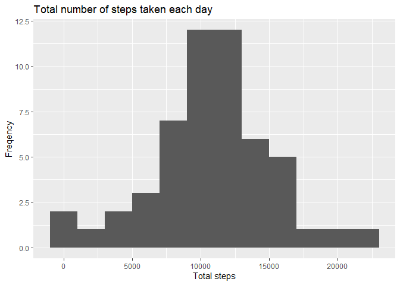

```r
steps_each_day<-activity%>%
  group_by(date)%>%
  summarise_at(vars(steps),list(sum=sum))
plot1<-ggplot(data=steps_each_day, aes(sum)) +
  geom_histogram(binwidth = 2000)+
  labs(title="Total number of steps taken each day") +
  labs(x="Total steps",y="Freqency")
plot1
```

```r
png(filename="plot1.png")
plot(plot1)
dev.off()
```

### 3 Mean and median number of steps taken each day

```r
mediaan<-median(steps_each_day$sum, na.rm=TRUE)
gemiddeld<-round(mean(steps_each_day$sum, na.rm=TRUE),2)
mediaan
```

```
## [1] 10765
```

```r
gemiddeld
```

```
## [1] 10766.19
```

The median of the number of steps taken each day is: 10765. The mean of the number of steps is: 10766.19

### 4 Time series plot of the average number of steps taken each interval

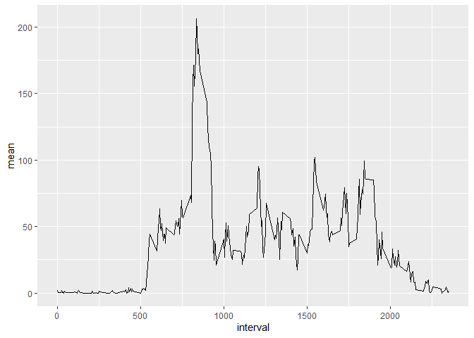

```r
steps_each_day_interval<-activity%>%
  group_by(interval)%>%
  summarise_at(vars(steps),list(mean=mean),na.rm=TRUE)
plot2<-ggplot(steps_each_day_interval, aes(interval, mean)) + geom_line()

plot2
```

```r
png(filename="plot2.png")
plot(plot2)
dev.off()
```

### 5 The 5-minute interval that, on average, contains the maximum number of steps

```r
avg_most_steps<-activity%>%                            # data frame
  group_by(interval) %>%                 # group indicator
  summarise_at(vars(steps),              # column
               list(gemiddeld = mean), na.rm=TRUE)
moststeps<-subset(avg_most_steps,gemiddeld==max(avg_most_steps$gemiddeld))
```

The maximum steps are 206.1698113 at interval 835.

### 6 Code to describe and show a strategy for imputing missing data

First of all w heave to check if and where missing data is. So we check all variables if any missing data exists

```r
s<-anyNA(activity$steps)
d<-anyNA(activity$date)
i<-anyNA(activity$interval)
```

Are there NA’s in activity$step TRUE

Are there NA’s in activity$date FALSE

Are there NA’s in activity$interval FALSE

Because this is a timeseries, I choose for the imputeTS package

First find out where the missing data is:

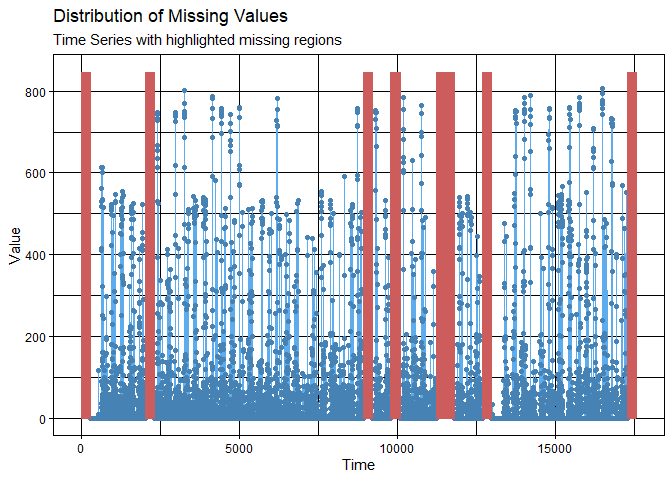

```r
#where are the missing data
plot3<- ggplot_na_distribution(activity$steps)
plot3
```

```r
png(filename="plot3.png")
plot(plot3)
dev.off()
```

Ok now its time to see what different impute methods are doing

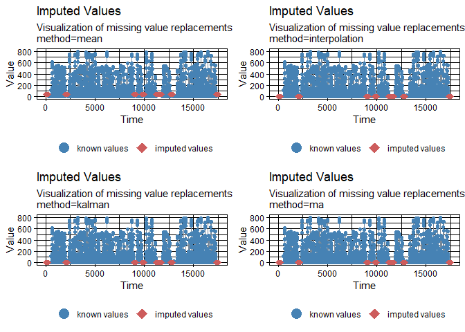

```r
imp_mean <- na_mean(activity$steps)
p1<-ggplot_na_imputations(activity$steps, imp_mean, subtitle= "Visualization of missing value replacements\nmethod=mean")
imp_interpolation <- na_interpolation(activity$steps)
p2<-ggplot_na_imputations(activity$steps, imp_interpolation, subtitle= "Visualization of missing value replacements\nmethod=interpolation")
imp_kalman <- na_kalman(activity$steps)
p3<-ggplot_na_imputations(activity$steps, imp_kalman, subtitle= "Visualization of missing value replacements\nmethod=kalman")
imp_ma <- na_ma(activity$steps)
p4<-ggplot_na_imputations(activity$steps, imp_ma, subtitle= "Visualization of missing value replacements \nmethod=ma")
#Overview of plots
plot7<-grid.arrange(p1, p2, p3, p4, nrow = 2)
```

```r
png(filename="plot7.png")
plot(plot7)
dev.off()
```

It looks like the method mean is the best method for imputing, so that will it be.

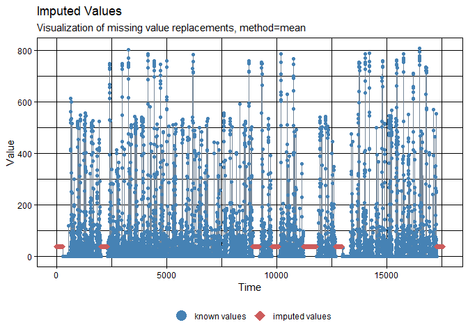

```r
imp_mean <- na_mean(activity$steps)
plot4<- ggplot_na_imputations(activity$steps, imp_mean, subtitle= "Visualization of missing value replacements, method=mean")
plot4
```

```r
png(filename="plot4.png")
plot(plot4)
dev.off()
```

### 7 Histogram of the total number of steps taken each day after missing values are imputed

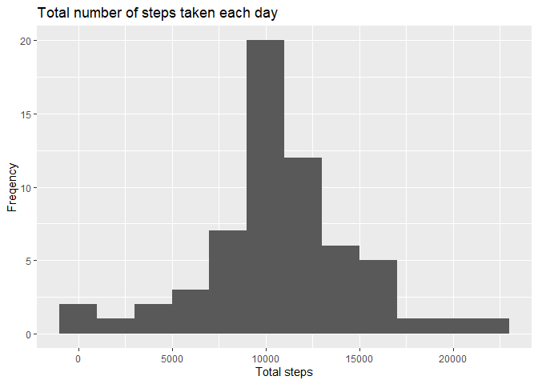

```r
activity_imp<-cbind(activity, imp_mean)
steps_each_day_imp<-activity_imp%>%
                group_by(date)%>%
                summarise_at(vars(imp_mean),list(sum=sum))
plot5<-ggplot(data=steps_each_day_imp, aes(sum)) +
      geom_histogram(binwidth = 2000)+
      labs(title="Total number of steps taken each day") +
      labs(x="Total steps",y="Freqency")
mediaan_imp<-median(steps_each_day_imp$sum, na.rm=TRUE)
gemiddeld_imp<-round(mean(steps_each_day_imp$sum, na.rm=TRUE),2)

plot5
```

```r
png(filename="plot5.png")
plot(plot5)
dev.off()
```

The median before imputing: 10765 and after imputing 10766.1886792 The mean before imputing: 10766.19 and after imputing 10766.19

### 8 Panel plot comparing the average number of steps taken per 5-minute interval across weekdays and weekends

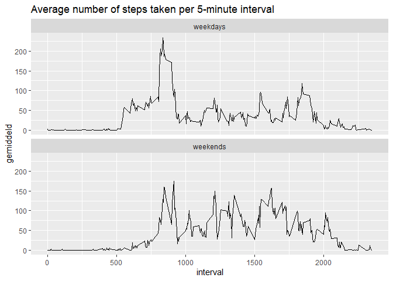

```r
avg_most_steps_comp<-activity%>%
                     mutate(weekday= ifelse((wday(date)==1 | wday(date)==7), "weekends", "weekdays")) %>%
                     group_by(weekday,interval) %>%
                     summarise_at(vars(steps), list(gemiddeld = mean), na.rm=TRUE)
d <- ggplot(avg_most_steps_comp, aes(interval,gemiddeld)) + geom_line()
d + facet_wrap(~ weekday,  dir = "v")+ labs(title="Average number of steps taken per 5-minute interval ")
```

```r
plot6<-d + facet_wrap(~ weekday,  dir = "v")+ labs(title="Average number of steps taken per 5-minute interval ")


png(filename="plot6.png")
plot(plot6)
dev.off()
```